# Landsat 8 y 9 L2: búsqueda y descarga desde Planetary Computer

## Uso

Instalar una vez en R:

```r
install.packages(c("rstac", "sf", "knitr"))
```

1. Editar polígono, fechas y destino en el primer bloque de código, con `ids <- character()`, y renderizar.
2. Revisar la tabla y el gráfico. Copiar el **id_producto** elegido.
3. Asignar, por ejemplo, `ids <- "LC08_L2SP_232083_20160209_20200907_02_T1"` y renderizar nuevamente. Se pueden incluir varios IDs de la tabla.

La búsqueda y la descarga desde [Microsoft Planetary Computer](https://planetarycomputer.microsoft.com/dataset/landsat-c2-l2) son públicas: no requieren cuenta. Las URL se firman automáticamente con un token temporal (SAS) que entrega el propio Planetary Computer.

Se descargan solo productos **Collection 2 Level-2** (colección `landsat-c2-l2`), escenas completas, sin recortar ni reproyectar. Cada producto queda en `<destino>/<id_producto>/` con todos sus GeoTIFF y el metadato `*_MTL.txt`, conservando los nombres originales de USGS. Los archivos ya descargados no se vuelven a descargar.

Para mayor información de las escenas y su procesamiento: https://www.usgs.gov/landsat-missions/landsat-collection-2-level-2-science-products

## Parámetros

```r
library(rstac)
library(sf)
desde   <- as.Date("2016-02-08")
hasta   <- as.Date("2016-02-10")
ids     <- character()  # p. ej. "LC08_L2SP_232083_20160209_20200907_02_T1"
destino <- "../../L8"

# AOI Mendoza, vértices en UTM 19S (EPSG:32619); el primero se repite para cerrar el anillo
vertices <- matrix(c(
  500000, -3660000,
  526000, -3660000,
  526000, -3644000,
  500000, -3644000,
  500000, -3660000
), ncol = 2, byrow = TRUE)
aoi <- st_transform(st_sfc(st_polygon(list(vertices)), crs = 32619), 4326)

stopifnot(desde <= hasta, all(st_is_valid(aoi)))
```

## Buscar escenas

```r
items <- stac("https://planetarycomputer.microsoft.com/api/stac/v1") |>
  stac_search(
    collections = "landsat-c2-l2",
    bbox = as.vector(st_bbox(aoi)),
    datetime = paste0(desde, "T00:00:00Z/", hasta, "T23:59:59Z"),
    limit = 100
  ) |>
  post_request() |>
  items_fetch()

# Solo Landsat 8 y 9 (OLI/TIRS)
escenas <- Filter(function(x) grepl("^LC0[89]_", x$id), items$features)
if (!length(escenas)) stop("No hay escenas Landsat 8/9 para este polígono y fechas.")

# El id de Planetary Computer omite la fecha de procesamiento; el id completo de USGS
# es la carpeta que contiene los archivos.
id_producto <- function(x) basename(dirname(sub("\\?.*", "", x$assets$mtl.txt$href)))

tabla <- do.call(rbind, lapply(escenas, function(x) data.frame(
  id_producto = id_producto(x),
  fecha = substr(x$properties$datetime, 1, 10),
  satelite = x$properties$platform,
  nubes_pct = x$properties[["eo:cloud_cover"]]
)))
tabla <- tabla[order(tabla$fecha, tabla$id_producto), ]
rownames(tabla) <- NULL
dir.create(destino, recursive = TRUE, showWarnings = FALSE)
write.csv(tabla, file.path(destino, "escenas.csv"), row.names = FALSE)
knitr::kable(tabla, digits = 2)
```

| id_producto | fecha | satelite | nubes_pct |
| --- | --- | --- | --- |
| LC08_L2SP_232083_20160209_20200907_02_T1 | 2016-02-09 | landsat-8 | 7.55 |

## Nubosidad

`eo:cloud_cover` es el porcentaje de nubes de **toda la escena**, no del polígono.

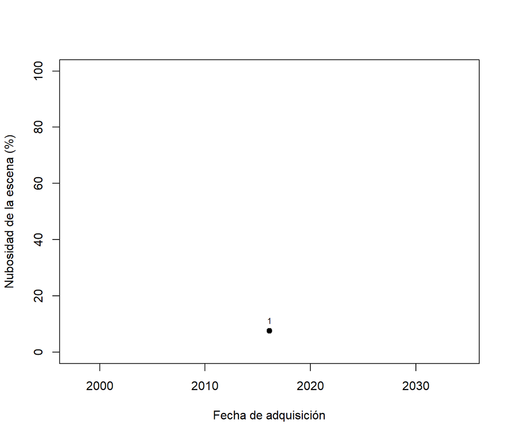

```r
plot(as.Date(tabla$fecha), tabla$nubes_pct, pch = 19, ylim = c(0, 100),
     xlab = "Fecha de adquisición", ylab = "Nubosidad de la escena (%)")
text(as.Date(tabla$fecha), tabla$nubes_pct, labels = seq_len(nrow(tabla)), pos = 3, cex = 0.7)
```

Los números sobre los puntos corresponden a las filas de la tabla y del CSV.

## Seleccion de la escena de interés

En este caso, selecciono solo la primer y unica escena:

```r
ids <- tabla$id_producto[1]
```

## Descargar los productos elegidos

```r
stopifnot(all(ids %in% tabla$id_producto))
options(timeout = 3600)  # download.file corta a los 60 s por defecto

# shortcut: el token SAS dura ~1 h; si se descargan muchas escenas, volver a firmar por escena.
firmadas <- items_sign(items, sign_planetary_computer())$features

for (x in firmadas) {
  id <- id_producto(x)
  if (!id %in% ids) next
  carpeta <- file.path(destino, id)
  dir.create(carpeta, showWarnings = FALSE)
  for (a in x$assets) {
    nombre <- basename(sub("\\?.*", "", a$href))
    if (!grepl("(\\.TIF|_MTL\\.txt)$", nombre)) next  # bandas y metadato txt
    final <- file.path(carpeta, nombre)
    if (file.exists(final)) next
    # .part evita dejar archivos truncados con el nombre final si se corta la descarga
    download.file(a$href, paste0(final, ".part"), mode = "wb", quiet = TRUE)
    file.rename(paste0(final, ".part"), final)
  }
  cat("Descargado:", id, "-", length(list.files(carpeta)), "archivos.\n")
}
```

```
Descargado: LC08_L2SP_232083_20160209_20200907_02_T1 - 21 archivos.
```

```r
if (!length(ids)) cat("Solo consulta. Para descargar, completar `ids` con IDs de la tabla.")
```

```r
library(terra)
carpeta <- file.path(destino, ids[1])
bandas <- file.path(carpeta, paste0(ids[1], "_SR_B", c(5, 4, 3), ".TIF"))  # NIR, rojo, verde
r <- rast(bandas)
r[r == 0] <- NA  # fill value
```

```
|---------|---------|---------|---------|
=========================================


|---------|---------|---------|---------|
=========================================
```

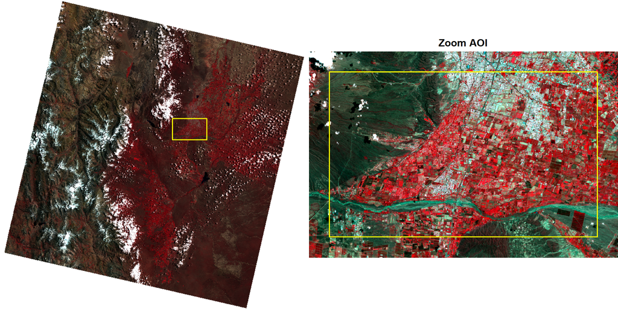

```r
aoi_r <- project(vect(aoi), crs(r))
zoom <- crop(r, ext(aoi_r) + 2000)  # 2 km de margen alrededor del AOI

par(mfrow = c(1, 2))
plotRGB(r, stretch = "lin", main = "Escena completa")
lines(aoi_r, col = "yellow", lwd = 2)
plotRGB(zoom, stretch = "lin", main = "Zoom AOI")
lines(aoi_r, col = "yellow", lwd = 2)
```

## Bandas, factores de escala y offset

Los GeoTIFF de nivel 2 se guardan como enteros. Para obtener la magnitud física se aplica, por banda:

$$\text{valor} = DN \times \text{factor} + \text{offset}$$

- Reflectancia superficial (SR_B1 a SR_B7): $\rho = DN \times 0.0000275 - 0.2$ (adimensional, rango válido 0 a 1).
- Temperatura superficial (ST_B10): $T = DN \times 0.00341802 + 149$ (Kelvin).
- Los píxeles con el *Fill Value* son sin dato y deben enmascararse antes de escalar.
- Las bandas QA son campos de bits: no se escalan.

Los mismos factores valen para Landsat 8 y 9 y figuran también en el `*_MTL.txt` (`REFLECTANCE_MULT_BAND_n`, `REFLECTANCE_ADD_BAND_n`, `TEMPERATURE_MULT_BAND_ST_B10`, `TEMPERATURE_ADD_BAND_ST_B10`). La columna *Asset PC* es el nombre del asset en Planetary Computer; el archivo descargado se llama `<id_producto>_<sufijo>`.

| Archivo | Asset PC | Banda | Longitud de onda (µm) | Tipo | Unidades | Rango | Fill Value | Factor | Offset |
| --- | --- | --- | --- | --- | --- | --- | --- | --- | --- |
| ProductID_SR_B1 | coastal | Band 1 SR (aerosol costero) | 0.43–0.45 | UINT16 | Reflectancia | 1-65535 | 0 | 0.0000275 | -0.2 |
| ProductID_SR_B2 | blue | Band 2 SR (azul) | 0.45–0.51 | UINT16 | Reflectancia | 1-65535 | 0 | 0.0000275 | -0.2 |
| ProductID_SR_B3 | green | Band 3 SR (verde) | 0.53–0.59 | UINT16 | Reflectancia | 1-65535 | 0 | 0.0000275 | -0.2 |
| ProductID_SR_B4 | red | Band 4 SR (rojo) | 0.64–0.67 | UINT16 | Reflectancia | 1-65535 | 0 | 0.0000275 | -0.2 |
| ProductID_SR_B5 | nir08 | Band 5 SR (NIR) | 0.85–0.88 | UINT16 | Reflectancia | 1-65535 | 0 | 0.0000275 | -0.2 |
| ProductID_SR_B6 | swir16 | Band 6 SR (SWIR 1) | 1.57–1.65 | UINT16 | Reflectancia | 1-65535 | 0 | 0.0000275 | -0.2 |
| ProductID_SR_B7 | swir22 | Band 7 SR (SWIR 2) | 2.11–2.29 | UINT16 | Reflectancia | 1-65535 | 0 | 0.0000275 | -0.2 |
| ProductID_ST_B10 | lwir11 | Band 10 ST (TIRS 1) | 10.60–11.19 | UINT16 | Kelvin | 1-65535 | 0 | 0.00341802 | 149 |
| ProductID_QA_PIXEL | qa_pixel | Level 2 Pixel Quality Band | NA | UINT16 | Bit Index | 1-65535 | 1 | NA | NA |
| ProductID_SR_QA_AEROSOL | qa_aerosol | Aerosol QA | NA | UINT8 | Bit Index | 0-255 | 1 | NA | NA |
| ProductID_QA_RADSAT | qa_radsat | Radiometric Saturation QA | NA | UINT16 | Bit Index | 0-65535 | NA | NA | NA |
| ProductID_ST_QA | qa | Surface Temperature Uncertainty | NA | INT16 | Kelvin | 0-32767 | -9999 | 0.01 | NA |
| ProductID_ST_TRAD | trad | Thermal Radiance | NA | INT16 | DN | 0-22000 | -9999 | 0.001 | NA |
| ProductID_ST_URAD | urad | Upwelled Radiance | NA | INT16 | DN | 0-28000 | -9999 | 0.001 | NA |
| ProductID_ST_DRAD | drad | Downwelled Radiance | NA | INT16 | DN | 0-28000 | -9999 | 0.001 | NA |
| ProductID_ST_ATRAN | atran | Atmospheric Transmittance | NA | INT16 | Unitless | 0-10000 | -9999 | 0.0001 | NA |
| ProductID_ST_EMIS | emis | Emissivity estimated from ASTER GED | NA | INT16 | Unitless | 0-10000 | -9999 | 0.0001 | NA |
| ProductID_ST_EMSD | emsd | Emissivity standard deviation | NA | INT16 | Unitless | 0-32767 | -9999 | 0.0001 | NA |
| ProductID_ST_CDIST | cdist | Pixel distance to cloud | NA | INT16 | Kilometers | 0-24000 | -9999 | 0.01 | NA |
| ProductID_MTL | mtl.txt | Level 2 Metadata file | NA | NA | NA | NA | NA | NA | NA |

Ejemplo con `terra` para pasar una banda SR a reflectancia:

```r
b4 <- terra::rast(list.files(file.path(destino, ids[1]), "_SR_B4\\.TIF$", full.names = TRUE))
b4[b4 == 0] <- NA
b4 <- b4 * 0.0000275 - 0.2
```

## Referencias

- [Planetary Computer: Landsat Collection 2 Level-2](https://planetarycomputer.microsoft.com/dataset/landsat-c2-l2).
- [rstac: búsqueda](https://brazil-data-cube.github.io/rstac/reference/stac_search.html) y [firma de URLs](https://brazil-data-cube.github.io/rstac/reference/items_sign.html).
- [USGS: Landsat 8-9 Collection 2 Level-2 Science Product Guide](https://www.usgs.gov/landsat-missions/landsat-collection-2-level-2-science-products).